# DGP Dossier: synth_nonlinear_heteroskedastic

## 1. Identity & Status

| DGP ID | synth_nonlinear_heteroskedastic |
| --- | --- |
| Version | 1.6.0 |
| Status | experimental |
| Difficulty | ★★★☆☆ (3/5) |
| Stress Profile | overlap: moderatenoise: heteroskedasticlinearity: smootheffect: constanttarget: both |

## 2. What This DGP Stresses (Intent)

Monotone nonlinear confounding + severe heteroskedasticity. OLS fails because it fits a plane to a cubic signal and cannot adapt to variance that explodes in the tails of the covariate distribution.

## 3. Identification Assumptions (Explicit)

- Selection on observables holds.
- Overlap is moderate (restored in v1.5.0, carried forward to v1.6.0).
- SUTVA holds.

## 4. Mathematical Specification

Covariates:
$$X_1 \sim \mathcal{N}(0, 1^2),\quad
X_2 \sim \mathcal{N}(0, 1^2),\quad
X_3 \sim \mathcal{U}[-2, 2],\quad
X_4 \sim \text{Bernoulli}(0.4)$$

Outcome (control):
$$\mu_0(X) = 1 + 0.5 X_1^3 + 1.5 X_2^2 - 1.0 X_4$$

Treatment Effect:
$$\tau(X) \equiv 1$$

Propensity:
$$p(X) = \mathrm{expit}(0.5 X_1 - 0.5 X_2)$$

Heteroskedastic noise:
$$\varepsilon \sim \mathcal{N}\!\left(0, \sigma^2(X)\right),\quad
\sigma(X) = 0.1 + 1.0\exp(0.5 X_2)$$

## 5. Oracle Truth Definition

- True ATT is computed from `structural_te` among treated units.
- True QST is computed on the oracle tau grid (`cs_get_oracle_qst()`).

## 6. Visual Diagnostics (n = 5000)

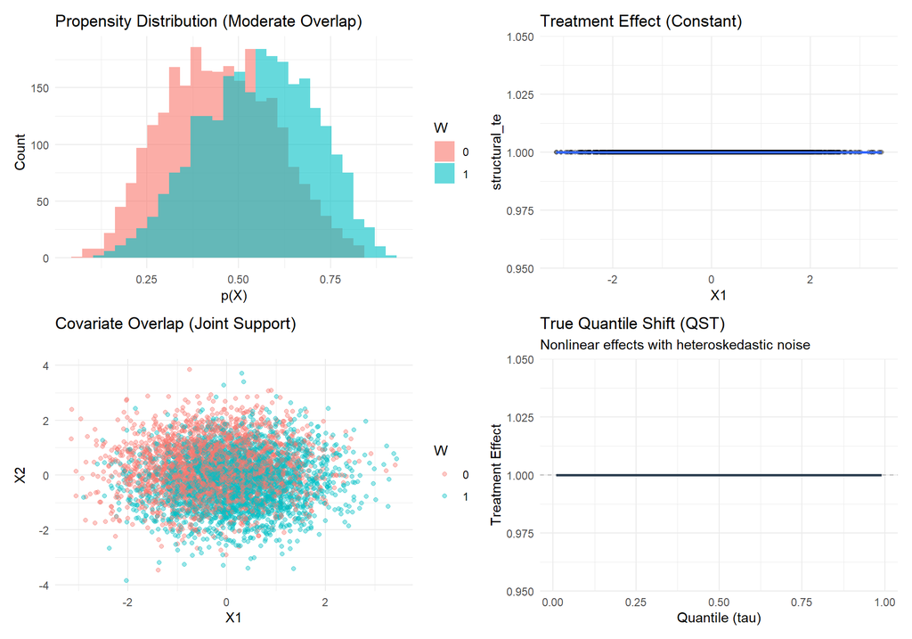

## 7. Empirical Validation

Under the v1.6.0 cubic/exponential regime (with overlap restored), OLS (`lm_att`) exhibits significant structural bias. While it avoids the variance explosion of severe overlap violations, the linear model cannot adapt to the cubic outcome surface. In quick validation (n = 1000, seeds = 1:10), `lm_att` shows mean bias around 0.32 (32% error), while `oracle_att` remains exact.

| estimator_id | mean_bias | rmse |
| --- | --- | --- |
| lm_att | 0.321 | 0.404 |
| oracle_att | 0.000 | 0.000 |

## 8. Failure Mode Summary

- Structural underfitting of nonlinear signal (linear model misspecification) drives ATT bias.
- Severe heteroskedasticity creates variance instability even under moderate overlap.

## 9. Implementation Reference

- Generator: `R/dgp-synth-nonlinear-heteroskedastic.R`
- Registry: `cs_dgp_registry()` entry for `synth_nonlinear_heteroskedastic`
- Oracle truth: `cs_get_oracle_qst("synth_nonlinear_heteroskedastic", version = "1.6.0")`

## 10. Validation Checklist

- mu0(X) specified (cubic + quadratic)
- sigma(X) specified (0.1 + exp(0.5 X2))
- X1 vs X2 titled “Covariate Overlap (Joint Support)”

## 11. Changelog

- v1.4.0: Parameter hardening (Deprecated v1.3.0).
- v1.5.0: Relaxed propensity coefficients to 0.5. v1.4.0 deprecated due to unintended overlap violation.
- v1.6.0: Implemented Common Random Numbers (CRN) for Oracle generation. Eliminates Monte Carlo noise in QST truth benchmarks.

## Appendix: Implementation

```
Source code for: dgp_synth_nonlinear_heteroskedastic_v160

function(n, seed = NULL, include_truth = TRUE, oracle_only = FALSE) {
  if (!is.null(seed)) {
    cs_set_rng(seed)
  }

  X1 <- stats::rnorm(n, mean = 0, sd = 1)
  X2 <- stats::rnorm(n, mean = 0, sd = 1)
  X3 <- stats::runif(n, min = -2, max = 2)
  X4 <- stats::rbinom(n, size = 1L, prob = 0.4)

  mu0 <- 1 + 0.5 * X1^3 + 1.5 * X2^2 - 1.0 * X4
  tau <- rep(1.0, n)

  sigma <- 0.1 + 1.0 * exp(0.5 * X2)
  eps0  <- stats::rnorm(n, mean = 0, sd = sigma)

  if (isTRUE(oracle_only)) {
    eps1 <- eps0
  } else {
    eps1 <- stats::rnorm(n, mean = 0, sd = sigma)
  }

  p <- stats::plogis(0.5 * X1 - 0.5 * X2)
  w <- stats::rbinom(n, size = 1L, prob = p)

  y0 <- mu0 + eps0
  y1 <- mu0 + tau + eps1

  if (isTRUE(oracle_only)) {
    return(list(df = tibble::tibble(w = w, y0 = y0, y1 = y1)))
  }
  y  <- ifelse(w == 1L, y1, y0)

  true_att <- cs_true_att(structural_te = tau, w = w)
  true_qst <- if (isTRUE(include_truth)) {
    cs_get_oracle_qst("synth_nonlinear_heteroskedastic", version = "1.6.0")
  } else {
    tibble::tibble(tau = cs_tau_oracle, value = rep(NA_real_, length(cs_tau_oracle)))
```

[output cut: 16 more lines]

```
    true_qst = true_qst,
    meta = list(
      dgp_id        = "synth_nonlinear_heteroskedastic",
      version       = "1.6.0",
      type          = "synthetic",
      params        = list(n = n, seed = seed),
      structural_te = tau
    )
  )

  cs_check_dgp_synthetic(out)
  out
}
<bytecode: 0x000001d55c361c80>
<environment: namespace:CausalStress>
```